# 3207_Assignment2

2022-10-25

## Setup

```r
library(pacman)
p_load(pacman, devtools, bookdown, tidyverse, ggforce, flextable, latex2exp, png, magick, metafor, rmcorr, readr, knitr)
install_github("daniel1noble/orchaRd", force = TRUE)
devtools::install_github("daniel1noble/orchaRd", force = TRUE)
library(orchaRd)
```

#### Repo Link: https://github.com/JadeFletcher/Ocean-Acidification-Assignment

## Transforming Clark et. al Data

```r
clark <- read_csv('data/OA_activitydat_20190302_BIOL3207 (1).csv') #Load Clark Paper
clark <- na.omit(clark)
clark <- clark %>% select(-loc, -comment, -...1) # Omit unnecessary cols
summary_clark <- clark %>% group_by(species, treatment, size) %>% summarise(across(c(activity), funs(mean, se=sd(.)/sqrt(n()), n())))

# Create cols similar to metadata
CO2 <- summary_clark[summary_clark$treatment == 'CO2',]
control <- summary_clark[summary_clark$treatment == 'control',]
to_meta <- cbind(CO2, control)%>% select(-7, -2, -8, -9) %>% rename(Species = species...1, ctrl.n = activity_n...12, ctrl.sd = activity_se...11, ctrl.mean = activity_mean...10, oa.n = activity_n...6, oa.sd = activity_se...5, oa.mean = activity_mean...4, 'Life stage' = size...3)

#rename variables in line with metadata
to_meta$`Life stage`[to_meta$`Life stage`=='big'] <- 'Adult'
to_meta$`Life stage`[to_meta$`Life stage`=='small'] <- 'Juvenile'

head(to_meta)
```

```
## # A tibble: 6 × 8
##   Species `Life stage` oa.mean oa.sd  oa.n ctrl.mean ctrl.sd ctrl.n
##   <chr>   <chr>          <dbl> <dbl> <int>     <dbl>   <dbl>  <int>
## 1 acantho Adult           30.6  2.65    24      24.7    2.93     27
## 2 acantho Juvenile        26.0  1.15    62      30.8    1.08     63
## 3 ambon   Adult           18.4  2.60    22      17.3    2.50     21
## 4 chromis Adult           24.8  2.93    14      26.1    2.04     20
## 5 humbug  Adult           40.3  1.51    62      34.9    1.72     65
## 6 lemon   Adult           26.0  2.51    19      19.8    2.24     30
```

## Merging to metadata

```r
entry <- cbind(to_meta, read_csv('data/clark_paper_data.csv')) %>% rename(Life.stage = 'Life stage', Year..online. = 'Year (online)',Year..print. = 'Year (print)', Pub.year.IF = 'Pub year IF', X2017.IF = '2017 IF', Average.n = 'Average n', Effect.type = 'Effect type', Climate..FishBase. = 'Climate (FishBase)', Env.cue.stimulus. = 'Env cue/stimulus?', Behavioural.metric = 'Behavioural metric', Cue.stimulus.type = 'Cue/stimulus type') %>% select(-23) #Creating consistent/callable column names

# Merging
metadata <- merge.data.frame(entry, read.csv('data/ocean_meta_data.csv'), all = TRUE)
head(metadata)
```

```
##                      Species Life.stage oa.mean  oa.sd oa.n ctrl.mean ctrl.sd
## 1 Hippocampus guttulatus\xca      Adult   6.250  6.944    6    26.389  12.500
## 2 Hippocampus guttulatus\xca      Adult   7.550  1.733    6    30.446  11.139
## 3 Hippocampus guttulatus\xca      Adult   8.333  7.639    6     9.082  15.278
## 4 Hippocampus guttulatus\xca      Adult  14.583 13.194    6    34.772  15.972
## 5 Hippocampus guttulatus\xca      Adult  31.944 31.944    6    34.722  18.750
## 6 Hippocampus guttulatus\xca      Adult  52.083 28.472    6    30.556  13.194
##   ctrl.n Study       Authors Year..online. Year..print.
## 1      6   a36 Faliero et al          2015         2015
## 2      6   a36 Faliero et al          2015         2015
## 3      6   a36 Faliero et al          2015         2015
## 4      6   a36 Faliero et al          2015         2015
## 5      6   a36 Faliero et al          2015         2015
## 6      6   a36 Faliero et al          2015         2015
##                                                                                                                                                 Title
```

[output cut: 20 more lines]

## Adding lnRR Effect Size

```r
metadata <- escalc(measure = 'ROMC', m1i = ctrl.mean, m2i = oa.mean, sd1i = ctrl.sd, sd2i = oa.sd, ri = rep(0, 826), ni = Average.n, data = metadata, var.names = c('effect.size', 'sampling.variance'))
metadata = na.omit(metadata)

head(metadata)
```

```
##
##                      Species Life.stage oa.mean  oa.sd oa.n ctrl.mean ctrl.sd
## 1 Hippocampus guttulatus\xca      Adult   6.250  6.944    6    26.389  12.500
## 2 Hippocampus guttulatus\xca      Adult   7.550  1.733    6    30.446  11.139
## 3 Hippocampus guttulatus\xca      Adult   8.333  7.639    6     9.082  15.278
## 4 Hippocampus guttulatus\xca      Adult  14.583 13.194    6    34.772  15.972
## 5 Hippocampus guttulatus\xca      Adult  31.944 31.944    6    34.722  18.750
## 6 Hippocampus guttulatus\xca      Adult  52.083 28.472    6    30.556  13.194
##   ctrl.n Study       Authors Year..online. Year..print.
## 1      6   a36 Faliero et al          2015         2015
## 2      6   a36 Faliero et al          2015         2015
## 3      6   a36 Faliero et al          2015         2015
## 4      6   a36 Faliero et al          2015         2015
## 5      6   a36 Faliero et al          2015         2015
## 6      6   a36 Faliero et al          2015         2015
```

[output cut: 28 more lines]

## Assessing Overall Effect Size

```r
MAM <- rma.mv(data = metadata, yi = effect.size, V = sampling.variance, random = list( ~1 | Study, ~1 | Behavioural.metric))
MAM
```

```
##
## Multivariate Meta-Analysis Model (k = 795; method: REML)
##
## Variance Components:
##
##             estim    sqrt  nlvls  fixed              factor
## sigma^2.1  0.4431  0.6657     91     no               Study
## sigma^2.2  3.2726  1.8090    718     no  Behavioural.metric
##
## Test for Heterogeneity:
## Q(df = 794) = 725443380.9169, p-val < .0001
##
## Model Results:
##
## estimate      se     zval    pval    ci.lb   ci.ub
##  -0.1661  0.1096  -1.5156  0.1296  -0.3808  0.0487
##
## ---
## Signif. codes:  0 '***' 0.001 '**' 0.01 '*' 0.05 '.' 0.1 ' ' 1
```

```r
predict(MAM, transf = "transf.ztor")
```

[output not shown]

From the model above we have obtained an overall meta analytic mean of -0.166. From this value alone we could assume that the overall effect size is negative, a reduction in the mean of the response variable. Looking further, a p-value of 0.13 was returned, so this result was most likely not significant. This is further supported by the 95% confidence intervals, with a range of -0.38 to 0.047.These bounds mean that in repetitions of these experiments, 95% of cases would have the mean effect size between these values. As they span over zero, there is very little certainty that the effect is at all directional.

```r
i2 <- orchaRd::i2_ml(MAM)
i2
```

```
##              I2_Total              I2_Study I2_Behavioural.metric
##             100.00000              11.92626              88.07374
```

```r
predict(MAM)
```

```
##
##     pred     se   ci.lb  ci.ub   pi.lb  pi.ub
##  -0.1661 0.1096 -0.3808 0.0487 -3.9502 3.6181
```

Looking further at heterogeneity estimates, the total I squared value indicates perfectly heterogenous effect size data, where sampling bias does not contribute to the effect variation. Furthermore, differences between studies only contributes 12% of the variation. Variation is greatest due to the behavioural metric used, contributing to 88% of variation. These startistics can all be visualised together in the below `plot`

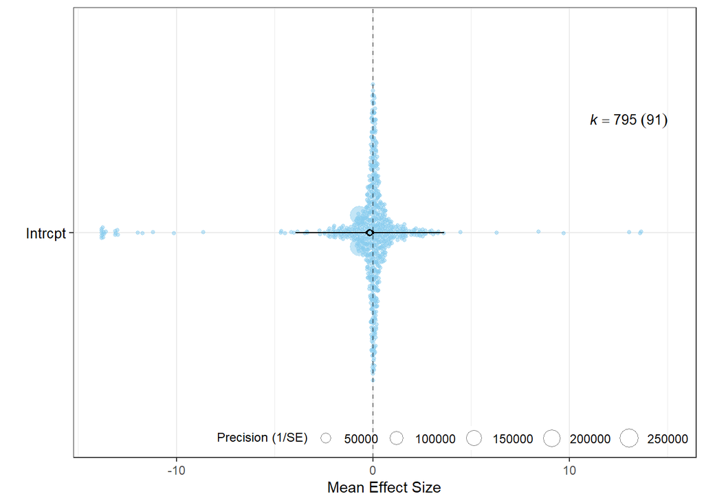

```r
orchard_plot(data = metadata, object = MAM, group = 'Study', xlab = 'Mean Effect Size', mod = 1, angle = 0) #Generate orchard plot
```

## Examining Publication Bias

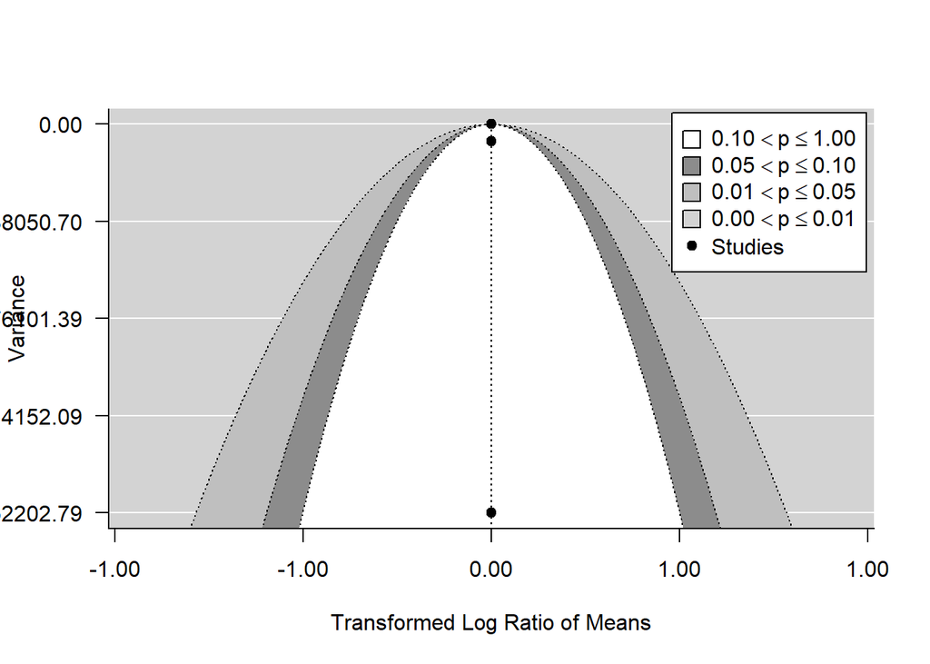

Figure 2. Funnel plot displaying effect size as a function of sampling variance. Shaded regions indicate p-values as per the legend displayed on the chart.

```r
funnel(x = metadata$effect.size, vi = metadata$sampling.variance, yaxis = 'vi',
    digits = 2, level = c(0.1, 0.05, 0.01), shade = c("white", "gray55", "gray 75"),
    las = 1, atransf = tanh, legend = TRUE) #generate funnel plot
```

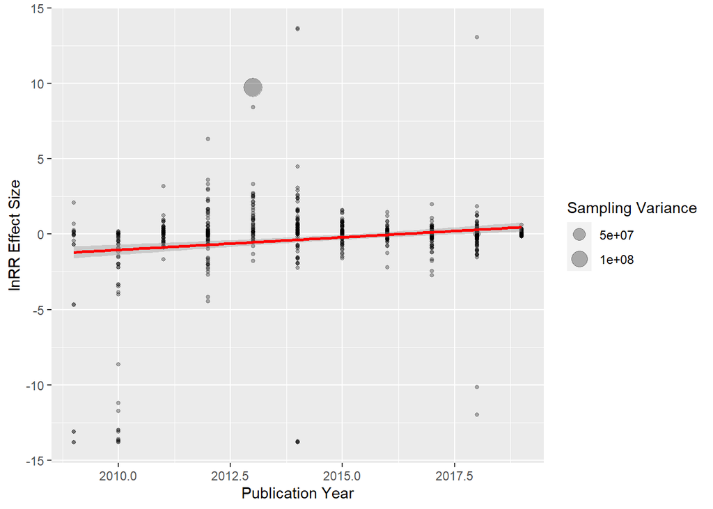

Figure 3. Plot of Effect size as a function of online publication year. Points scaled with respect to sampling variance.

```r
ggplot(metadata, aes(y = effect.size, x = Year..online., size = sampling.variance)) + geom_point(alpha = 0.3) +
    geom_smooth(method = lm, col = "red", show.legend = FALSE) + labs(x = "Publication Year",
    y = "lnRR Effect Size", size = "Sampling Variance") # Plot time-lag
```

Generating a funnel-plot from the effect size as a function on sampling variance is shown in figure 2. Although the typical dome-shape is produced, very few of the studies are displayed on the plot.Here is unclear whether publication bias has impacted the result.

Continuing on to look at time-lag bias, Visual inspection of the trend in figure 3 indicates potentially some positive relationship with year, though the dpread of effect size does seem to vary somewhat randomly by year. Metaregression assists to further clarify the visual assessment.

```r
MAMlag <- rma.mv(effect.size ~ Year..online., V = sampling.variance, random = list(~1 | Study, ~1 | Behavioural.metric), test = "t", dfs = "contain", data = metadata)
summary(MAMlag) #Modelling time-lag
```

```
##
## Multivariate Meta-Analysis Model (k = 795; method: REML)
##
##     logLik    Deviance         AIC         BIC        AICc
## -1753.8049   3507.6098   3515.6098   3534.3131   3515.6606
##
## Variance Components:
##
##             estim    sqrt  nlvls  fixed              factor
## sigma^2.1  0.4161  0.6451     91     no               Study
## sigma^2.2  3.2752  1.8098    718     no  Behavioural.metric
##
## Test for Residual Heterogeneity:
## QE(df = 793) = 150009174.5467, p-val < .0001
##
## Test of Moderators (coefficient 2):
## F(df1 = 1, df2 = 89) = 3.7490, p-val = 0.0560
##
## Model Results:
##
##                 estimate       se     tval  df    pval      ci.lb   ci.ub
## intrcpt        -147.4247  76.0540  -1.9384  89  0.0557  -298.5424  3.6929  .
## Year..online.     0.0731   0.0377   1.9362  89  0.0560    -0.0019  0.1481  .
##
## ---
## Signif. codes:  0 '***' 0.001 '**' 0.01 '*' 0.05 '.' 0.1 ' ' 1
```

```r
MAMfile <- metareg_time <- rma.mv(effect.size ~ Year..online. + sampling.variance, V = sampling.variance, random = list(~1 | Study, ~1 | Behavioural.metric),test = "t", dfs = "contain", data = metadata) #Modelling lag and file-drawer effect

MAMlag
```

```
##
## Multivariate Meta-Analysis Model (k = 795; method: REML)
##
## Variance Components:
##
##             estim    sqrt  nlvls  fixed              factor
## sigma^2.1  0.4161  0.6451     91     no               Study
## sigma^2.2  3.2752  1.8098    718     no  Behavioural.metric
##
## Test for Residual Heterogeneity:
## QE(df = 793) = 150009174.5467, p-val < .0001
##
## Test of Moderators (coefficient 2):
## F(df1 = 1, df2 = 89) = 3.7490, p-val = 0.0560
##
## Model Results:
##
##                 estimate       se     tval  df    pval      ci.lb   ci.ub
## intrcpt        -147.4247  76.0540  -1.9384  89  0.0557  -298.5424  3.6929  .
## Year..online.     0.0731   0.0377   1.9362  89  0.0560    -0.0019  0.1481  .
##
## ---
## Signif. codes:  0 '***' 0.001 '**' 0.01 '*' 0.05 '.' 0.1 ' ' 1
```

```r
r2_ml(MAMlag)
```

```
##    R2_marginal R2_conditional
##     0.01123816     0.12270541
```

By again applying the Meta-Analysis model we see that time-lag does not appear to have a significant impact of effect size over the years and would only account for ~1% of variation if it did.

```r
MAMfile
```

```
##
## Multivariate Meta-Analysis Model (k = 795; method: REML)
##
## Variance Components:
##
##             estim    sqrt  nlvls  fixed              factor
## sigma^2.1  0.4161  0.6451     91     no               Study
## sigma^2.2  3.2752  1.8098    718     no  Behavioural.metric
##
## Test for Residual Heterogeneity:
## QE(df = 792) = 150009174.5466, p-val < .0001
##
## Test of Moderators (coefficients 2:3):
## F(df1 = 2, df2 = 88) = 1.8745, p-val = 0.1595
##
## Model Results:
##
##                     estimate       se     tval   df    pval      ci.lb   ci.ub
## intrcpt            -147.4247  76.0540  -1.9384   88  0.0558  -298.5660  3.7166
## Year..online.         0.0731   0.0377   1.9362   88  0.0560    -0.0019  0.1481
## sampling.variance     0.0000   0.0001   0.0013  792  0.9990    -0.0002  0.0002
##
## intrcpt            .
## Year..online.      .
## sampling.variance
##
## ---
## Signif. codes:  0 '***' 0.001 '**' 0.01 '*' 0.05 '.' 0.1 ' ' 1
```

```r
r2_ml(MAMfile)
```

```
##    R2_marginal R2_conditional
##     0.08208274     0.18556342
```

Including sampling variance to account for file-drawer effects yielded a similar result, suggesting time-lag and file-drawer biases in the data is unlikely.